# Intro to Numpy

### Conditional Access of arrays

if a here was a single element , wirintg a>2 wil gegenrate True or False depeneding on whetrher that particular consition was true.

Now when a is a numpy array, that comparison will be done for each element and result will be an array of shape same as a ; containing True/False for each element.

```python
a = np.array([[1,2], [3, 4], [5, 6]])
a
```

```
array([[1, 2],
       [3, 4],
       [5, 6]])
```

```python
zz = np.array([(1,0,1),(1,0,1)])
print(zz)
print()
zz[:] = 101
print(zz)
```

```
[[1 0 1]
 [1 0 1]]

[[101 101 101]
 [101 101 101]]
```

```python
c=a > 2
print(c,a)
```

```
[[False False]
 [ True  True]
 [ True  True]] [[1 2]
 [3 4]
 [5 6]]
```

We can use , these comparison expressions directly for access. Result is only those elements for which the expression evaluates to True

```python
print(a[c])
print(a[c].shape)
a.shape
```

```
[3 4 5 6]
(4,)
```

```
(3, 2)
```

notice that the result is a 1D array.

Lets see if this works with writing mulitple conditions as well. In that process we'll also see that we dont have to store results in one variable and then pass for subsetting. We can instead, write the conditional expression directly for subsetting.

```python
a
a[(a>2) | (a<5)]
```

```
array([1, 2, 3, 4, 5, 6])
```

```python
a[(a>2) & (a<5)]
```

```
array([3, 4])
```

### Array Operations

We'll see that you can use ; both normal symbols as well as numpy functions for array operations. Lets look at these operations with examples

```python
x = np.array([[1,2],[3,4]])
y = np.array([[5,6],[7,8]])
```

```python
x
```

```
array([[1, 2],
       [3, 4]])
```

```python
y
```

```
array([[5, 6],
       [7, 8]])
```

```python
x+y
```

```
array([[ 6,  8],
       [10, 12]])
```

```python
np.add(x,y)
```

```
array([[ 6,  8],
       [10, 12]])
```

```python
print(x-y)
```

```python
np.subtract(x,y)
```

```python
# element wise multiplication , not matrix multiplication
print(x)
print("~~~~~")

print(y)
print("~~~~~")
print(x * y)
```

```python
np.multiply(x, y)
```

```python
print(x/y)
```

```python
np.divide(x,y)
```

In general you'll find that , mathematical functions from numpy [being referred as np here ] when applied on array, give back result as an array where that function has been applied on individual elements. These function from package math on the other hand give error when applied to arrays. They only work for scalars.

```python
x
```

```
array([[1, 2],
       [3, 4]])
```

```python
np.sqrt(x)
```

```
array([[1.        , 1.41421356],
       [1.73205081, 2.        ]])
```

```python
import math
math.sqrt(x)
```

```
---------------------------------------------------------------------------
TypeError                                 Traceback (most recent call last)
<ipython-input-30-346d560305e8> in <module>
      1 import math
----> 2 math.sqrt(x)

TypeError: only size-1 arrays can be converted to Python scalars
```

```python
v = np.array([9,10])
v
```

```python
w = np.array([11, 12])
w
```

```python
# Matrix multiplication
v.dot(w)
```

```python
# 1*2 -- 2*1
```

```python
v=v.reshape((1,2))
w=w.reshape((1,2))
```

```python
np.dot(v,w)
```

```python
print('matrix v : ',v)
print('matrix v Transpose:',v.T)
print('matrix w:',w)
print('matrix w Transpose:',w.T)
print('~~~~~~~~~')
print(np.dot(v,w.T))
print('~~~~~~~~~')
print(np.dot(v.T,w))
```

```python
print(x)
print("~~~")
print(y)
x.dot(y)
```

### other functions

```python
x = np.array([[1,2],[3,4]])
x
```

```python
np.sum(x)
```

Using axis option in the function sum , you can some across both the dimension of array separately as well

```python
np.sum(x, axis=0)
```

```python
np.sum(x, axis=1)
```

So far we have seen that, when we do operations between two arrays; operation happens between corresponding elements of the arrays. Many at times , shape of arrays will not match and correspondence between elements will not be complete. In such case , elements of the smaller array are recycled to makeup for the correspondence.

```python
x = np.array([[1,2,3], [4,5,6], [7,8,9], [10, 11, 12]])
v = np.array([1, 0, 1])
v
```

```
array([1, 0, 1])
```

```python
vv = np.tile(v, (4, 1))  # Stack 4 copies of v on top of each other
vv
```

```
array([[1, 0, 1],
       [1, 0, 1],
       [1, 0, 1],
       [1, 0, 1]])
```

```python
print(np.hstack((v,v)))
np.vstack((v,v))
```

```python
print(x)
print("~~~~~")
print(vv)
x + vv
```

```
[[ 1  2  3]
 [ 4  5  6]
 [ 7  8  9]
 [10 11 12]]
~~~~~
[[1 0 1]
 [1 0 1]
 [1 0 1]
 [1 0 1]]
```

```
array([[ 2,  2,  4],
       [ 5,  5,  7],
       [ 8,  8, 10],
       [11, 11, 13]])
```

**Python Numpy Special Functions**

```python
import numpy as np
np.sin(np.array((0, 30., 45., 60., 90.)) * np.pi / 180. )
```

```
array([0.        , 0.5       , 0.70710678, 0.8660254 , 1.        ])
```

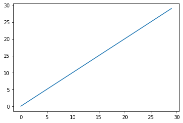

```python
#There are various special functions available in numpy such as sine, cosine, tan, log etc
import numpy as np
import matplotlib.pyplot as plt
# to print the graph in line to the cell
%matplotlib inline
x= np.arange(0,3*np.pi,0.1)
# print(x)
y=np.sin(x)

x2 = np.arange(30)
y2 = np.array([(x22-1) for x22 in range(1,31) if x22 > 0])

x
plt.plot(x2,y2)
plt.show()
```

[output not shown]

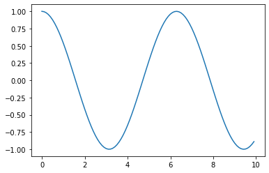

```python
import numpy as np
import matplotlib.pyplot as plt
x= np.arange(0,10,0.1)
print(x)
y=np.cos(x)
plt.plot(x,y)
plt.show()
```

```python
#Exp
a= np.array([1,2,3])
print(np.exp(a))
```

```
[ 2.71828183  7.3890561  20.08553692]
```

```python
# np.arange(10)
```

```python
#log
import numpy as np
import matplotlib.pyplot as plt
a= np.array([1,2,3])
print(np.log(a))
```

```
[0.         0.69314718 1.09861229]
```

## An Introduction to Pandas in Python

Pandas is a software library written for the Python programming language. It is used for data manipulation and analysis. It provides special data structures and operations for the manipulation of numerical tables and time series.

Pandas is the name for a Python module, which is rounding up the capabilities of Numpy, Scipy and Matplotlab. The word pandas is an acronym which is derived from "Python and data analysis" and "panel data".

```python
#pip install pandas
import pandas as pd
```

### Data structures in pandas

**Dataframe and series**

**A DataFrame is a two-dimensional array of values with both a row and a column index.**

**A Series is a one-dimensional array of values with an index.**

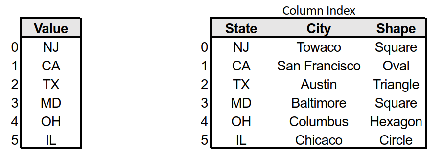

If it looks like the picture on the left is also present in the picture on the right, you’re right! Where a DataFrame is the entire dataset, including all rows and columns — a Series is essentially a single column within that DataFrame.

### Series

A Series is a one-dimensional labelled array-like object. It is capable of holding any data type, e.g. integers, floats, strings, Python objects, and so on. It can be seen as a data structure with two arrays: one functioning as the index, i.e. the labels, and the other one contains the actual data

```python
import pandas as pd
S = pd.Series([11, 28, 72, 3, 5, 8])
print(S)
```

```
0    11
1    28
2    72
3     3
4     5
5     8
dtype: int64
```

We haven't defined an index in our example, but we see two columns in our output: The right column contains our data, whereas the left column contains the index. Pandas created a default index starting with 0 going to 5, which is the length of the data minus 1.

```python
print(S.index)
print(S.values)
```

```
RangeIndex(start=0, stop=6, step=1)
[11 28 72  3  5  8]
```

**Difference between Numpy array and Series**

There is often some confusion about whether Pandas is an alternative to Numpy, SciPy and Matplotlib. The truth is that it is built on top of Numpy. This means that Numpy is required by pandas. Scipy and Matplotlib on the other hand are not required by pandas but they are extremely useful. That's why the Pandas project lists them as "optional dependency".

```python
import numpy as np
X = np.array([11, 28, 72, 3, 5, 8])
print(X)
print(S.values)
# both are the same type:
print(type(S.values), type(X))
print(type(S))
```

```
[11 28 72  3  5  8]
[11 28 72  3  5  8]
<class 'numpy.ndarray'> <class 'numpy.ndarray'>
<class 'pandas.core.series.Series'>
```

```python
#What is the actual difference
fruits = ['apples', 'oranges', 'cherries', 0] #We can define Series objects with individual indices(We can use arbitrary indices.)
quantities = [20, 33, 52, 10]
S = pd.Series(quantities, index=fruits)
s2 = pd.Series(quantities)
print(S+s2)
```

```
0           30.0
1            NaN
2            NaN
3            NaN
apples       NaN
cherries     NaN
oranges      NaN
dtype: float64
```

```python
print(S, s2, sep="\n\n")
```

[output not shown]

```python
#add two series with the same indices, we get a new series with the same index and the correponding values will be added
fruits = ['apples', 'oranges', 'cherries', 'pears']

S = pd.Series([20, 33, 52, 10], index=fruits)
S2 = pd.Series([17, 13, 31, 32], index=fruits)
S = S + S2
print(S)
print("sum of S: ", sum(S))
```

```
apples      37
oranges     46
cherries    83
pears       42
dtype: int64
sum of S:  208
```

```python
#The indices do not have to be the same for the Series addition. The index will be the "union" of both indices.
#If an index doesn't occur in both Series, the value for this Series will be NaN
fruits = ['peaches', 'oranges', 'cherries', 'pears']
fruits2 = ['raspberries', 'oranges', 'cherries', 'pears']

S = pd.Series([20, 33, 52, 10], index=fruits)
S2 = pd.Series([17, 13, 31, 32], index=fruits2)
print(S + S2)
```

```
cherries       83.0
oranges        46.0
peaches         NaN
pears          42.0
raspberries     NaN
dtype: float64
```

```python
#indices can be completely different, as in the following example.
#We have two indices. One is the Turkish translation of the English fruit names:
fruits = ['apples', 'oranges', 'cherries', 'pears','abc']

fruits_tr = ['elma', 'portakal', 'kiraz', 'armut']

S = pd.Series([20, 33, 52, 10,15], index=fruits)
S2 = pd.Series([17, 13, 31, 32], index=fruits_tr)
print(S + S2)
```

```
abc        NaN
apples     NaN
armut      NaN
cherries   NaN
elma       NaN
kiraz      NaN
oranges    NaN
pears      NaN
portakal   NaN
dtype: float64
```

### Series indexing

```python
a = [1,2,3,4]
a[0]
```

```
1
```

```python
S
```

```
apples      20
oranges     33
cherries    52
pears       10
abc         15
dtype: int64
```

```python
print('Single Indexing',S['apples'])
print('@@@@@@@@@@@@@@@@')
print('Multi Indexing ',S[['apples', 'oranges', 'cherries']])
```

```
Single Indexing 20
@@@@@@@@@@@@@@@@
Multi Indexing  apples      20
oranges     33
cherries    52
dtype: int64
```

### pandas.Series.apply

The function "func" will be applied to the Series and it returns either a Series or a DataFrame, depending on "func".

Parameter Meaning func a function, which can be a NumPy function that will be applied to the entire Series or a Python function that will be applied to every single value of the series convert_dtype A boolean value. If it is set to True (default), apply will try to find better dtype for elementwise function results. If False, leave as dtype=object args Positional arguments which will be passed to the function "func" additionally to the values from the series. **kwds Additional keyword arguments will be passed as keywords to the function

```python
#Ex
print(S)
print()

print(S.apply(np.log))
print()
print(np.log(S))
```

```
apples      20
oranges     33
cherries    52
pears       10
abc         15
dtype: int64

apples      2.995732
oranges     3.496508
cherries    3.951244
pears       2.302585
abc         2.708050
dtype: float64

apples      2.995732
oranges     3.496508
cherries    3.951244
pears       2.302585
abc         2.708050
dtype: float64
```

```python
S
```

```
apples      20
oranges     33
cherries    52
pears       10
abc         15
dtype: int64
```

```python
def fn():
    if x>50:
        pass
    else:
        x+10
```

```python
# Let's assume, we have the following task. The test the amount of fruit for every kind.
#If there are less than 50 available, we will augment the stock by 10:

S.apply(lambda x: x if x > 50 else x+10)
S.apply(fn())
```

```
---------------------------------------------------------------------------
ValueError                                Traceback (most recent call last)
<ipython-input-61-a51f1499c386> in <module>
      3
      4 S.apply(lambda x: x if x > 50 else x+10)
----> 5 S.apply(fn())

<ipython-input-60-6fb667386e95> in fn()
      1 def fn():
----> 2     if x>50:
      3         pass
      4     else:
      5         x+10

ValueError: The truth value of an array with more than one element is ambiguous. Use a.any() or a.all()
```

```python
S
```

```python
#Conditioning in a series
S[S==33]
# S>30
```

```
oranges    33
dtype: int64
```

```python
"oranges" in S
```

```
True
```

```python
#Creating Series Objects from Dictionaries
cities = {"London":    8615246,
          "Berlin":    3562166,
          "Madrid":    3165235,
          "Rome":      2874038,
          "Paris":     2273305,
          "Vienna":    1805681,
          "Bucharest": 1803425,
          "Hamburg":   1760433,
          "Budapest":  1754000,
          "Warsaw":    1740119,
          "Barcelona": 1602386,
          "Munich":    1493900,
          "Milan":     1350680}

city_series = pd.Series(cities)
print(city_series)
```

```
London       8615246
Berlin       3562166
Madrid       3165235
Rome         2874038
Paris        2273305
Vienna       1805681
Bucharest    1803425
Hamburg      1760433
Budapest     1754000
Warsaw       1740119
Barcelona    1602386
Munich       1493900
Milan        1350680
dtype: int64
```

### Handling missing data in pandas

One problem in dealing with data analysis tasks consists in missing data. Pandas makes it as easy as possible to work with missing data.

```python
my_cities = ["London", "Paris", "Zurich", "Berlin",
             "Stuttgart", "Hamburg"]

my_city_series = pd.Series(cities,
                           index=my_cities)
my_city_series
```

```
London       8615246.0
Paris        2273305.0
Zurich             NaN
Berlin       3562166.0
Stuttgart          NaN
Hamburg      1760433.0
dtype: float64
```

Due to the Nan values the population values for the other cities are turned into floats. There is no missing data in the 9following examples, so the values are int:

```python
my_cities = ["London", "Paris", "Berlin", "Hamburg"]

my_city_series = pd.Series(cities,
                           index=my_cities)
my_city_series
```

```
London     8615246
Paris      2273305
Berlin     3562166
Hamburg    1760433
dtype: int64
```

```python
#Finding whether a data is null or not
my_cities = ["London", "Paris", "Zurich", "Berlin",
             "Stuttgart", "Hamburg"]

my_city_series = pd.Series(cities,
                           index=my_cities)
print(my_city_series.isnull())
```

```
London       False
Paris        False
Zurich        True
Berlin       False
Stuttgart     True
Hamburg      False
dtype: bool
```

```python
print(my_city_series.isnull().sum())
my_city_series.notnull().sum()
my_city_series.isnull().sum()
```

```
2
```

```
2
```

```python
#Drop the nulls
print(my_city_series.dropna())
```

```
London     8615246.0
Paris      2273305.0
Berlin     3562166.0
Hamburg    1760433.0
dtype: float64
```

```python
#Fill the nulls
print(my_city_series.fillna(10200))
```

```
London       8615246.0
Paris        2273305.0
Zurich         10200.0
Berlin       3562166.0
Stuttgart      10200.0
Hamburg      1760433.0
dtype: float64
```

```python
missing_cities = {"London": 1, "Zurich":378884}
my_city_series.fillna(missing_cities)
```

```
London       8615246.0
Paris        2273305.0
Zurich        378884.0
Berlin       3562166.0
Stuttgart          NaN
Hamburg      1760433.0
dtype: float64
```

```python
my_city_series
```

[output not shown]

```python
#Still the values are not integers, we can convert it into int
print( my_city_series.fillna(1000).astype(int))
```

```
London       8615246
Paris        2273305
Zurich          1000
Berlin       3562166
Stuttgart       1000
Hamburg      1760433
dtype: int32
```

```python
ser1 = pd.Series(['a','b','c'])
ser1
```

```
0    a
1    b
2    c
dtype: object
```

```python
ser1= ser1.map({'a':1,'b':2,'c':3})
print(ser1)
```

```
0    1
1    2
2    3
dtype: int64
```

```python
ser1.index = ser1.index.map({0:2,1:4,2:6})
```

```python
ser1
```

```
2    1
4    2
6    3
dtype: int64
```